# VU [183.653](https://tiss.tuwien.ac.at/course/courseDetails.xhtml?courseNr=183653) Methodical, industrial Software-Engineering using the Haskell **fun**ctional programming language

2013-04-08

# Last Time

- GHC & Haskell Platform
- Haskell 98/2010 & Haskell Language Report
- WHNF & ⊥
- Partial/Total Functions
- Types, Kinds, Polymorphism & Typeclasses
- Module System
- The `IO` type & `do` syntax-sugar
- *Haskell kernel* sub-language

# Today

- GHC's Memory Management
- Value representation on the heap
  - `String` vs. `ByteString`/`Text`
  - `[a]` vs. `Vector`

# Garbage

```haskell
factorial :: Integer -> Integer
factorial n = go (n `max` 0) 1
  where
    go 0 a = a
    go i a = go (i-1) $! (a*i)
```

- `$!` is used to make sure the accumulator value `a` is strictly evaluated.
- But values in Haskell are (usually) immutable, and therefore `go` constructs two new `Integer` values on each recursion step.
- But only the final value of `a` is of interest after `factorial` terminates, every temporary value constructed during the computation is **Garbage** now.
- So in Haskell we create a lot of Garbage due to data immutability.

# Garbage Collection

- GHC uses a so-called **generational, copying collector**
  - "generational hypothesis": Most objects die young
  - Heap is divided into *Generations*
  - Whenever generation *n* is collected, so are all younger generations *m* < *n*
  - Objects get promoted to the next generation if they survive the GC cycle(s)
  - defragmentation is achieved by copying the live data

# Garbage Collection *(cont.)*

- GHC's runtime-system (RTS) exposes has a couple of parameters via special CLI options. When compiling a Haskell program via

  ```
  echo 'main = putStrLn "Hello World"' > HelloWorld.hs
  ghc --make -O -rtsopts HelloWorld.hs
  ```

  you can query the executable via `./Helloworld +RTS --help` to get a list of currently customizable RTS parameters.
- Default configuration:
  - Rather small 512k "Nursery" area (`+RTS -A<size>` option)
  - 2 Generations (`+RTS -G<n>` option)
- When "Nursery" area is exhausted a GC is triggered to free up memory!

# Garbage Collection *(cont.)*

- It's often beneficial to increase the allocation/nursery area (`+RTS -A<size>`) to match today's cpu cache-sizes.
- Using `+RTS -qg1` which allows parallel GC only for major collections sometimes helps for multicore programs.
- `+RTS -I<seconds>` configures the idle-timer for triggering major collections. In interactive applications the default 300ms setting might not be sensible.
- `+RTS -M<size>` allows to set the maximum heap size (*unlimited* by default). Note: when heap size nears configured maximum, a compaction algorithm is used instead of the default copying collection algorithm.

# Garbage Collection *(cont.)*

- Runtime statistics can be generated by `+RTS -s`:

  ```
      36,169,392 bytes allocated in the heap
       4,057,632 bytes copied during GC
       1,065,272 bytes maximum residency (2 sample(s))
          54,312 bytes maximum slop
               3 MB total memory in use (0 MB lost due to fragmentation)

  Generation 0:    67 collections,     0 parallel,  0.04s,  0.03s elapsed
  Generation 1:     2 collections,     0 parallel,  0.03s,  0.04s elapsed

  SPARKS: 359207 (557 converted, 149591 pruned)

  INIT  time    0.00s  (  0.00s elapsed)
  MUT   time    0.01s  (  0.02s elapsed)
  GC    time    0.07s  (  0.07s elapsed)
  EXIT  time    0.00s  (  0.00s elapsed)
  Total time    0.08s  (  0.09s elapsed)

  %GC time      89.5%  (75.3% elapsed)

  Alloc rate    4,520,608,923 bytes per MUT second

  Productivity  10.5% of total user, 9.1% of total elapsed
  ```

# Heap Objects

- Heap objects on the heap have the following basic structure:

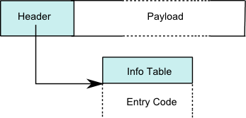

- Heap objects sizes are multiples of word-size (i.e. 32bit or 64bit)
- The "Info Table" contains information needed by the GC such as:
  - size of the payload
  - where pointers to other heap objects are located in the payload

# `Int` on the Heap

- Let's start with `Int`:

  ```haskell
  > :info Int
  data Int = GHC.Types.I# GHC.Prim.Int#   -- Defined in `GHC.Types'
  ```

- Types with the `MagicHash`, i.e. `Int#` are special primitive **unboxed** types provided by GHC.
- Unboxed types represent "raw" values for no "info table" exists.
- Unboxed types have the special kind `#` (so that you can't mix them up with normal `*` kinded types by accident).

# `Int` on the Heap *(cont.)*

- Using record-style diagrams, the `Int` type

  ```haskell
  data Int = I# Int#
  ```

  can be visualized as

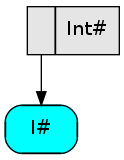

- Each rectangular field represents word-size (i.e. 32bit or 64bit)
- Empty fields contain pointers
- Rounded nodes represent a constructor's info-table/entry-code

# `Char` on the Heap

- Similiar to `Int#`:

  ```haskell
  data Char = C# Char#
  ```

  leads to

[figure not shown]

- Optimization in GHC: pre-allocated shared heap-objects for latin-1 subset of `Char` (likewise for `Int`: − 17 < *n* < 17)